# Introduction to MultivarTV

Brayan Ortiz

2018-05-07

# Abstract

Total variation is a widely applicable regularization problem that is commonly used in signal and image denoising. We introduce the $\tt{R}$ package $\bf{MultivarTV}$, which is used for solving the multivariate total variation problem. Using an alternating direction method of multipliers algorithm (ADMM), we are able to solve problems large in sample size and number of features.

# Introduction

To introduce total variation, we consider the univariate or one-dimensional case first. We begin by observing a response $y_i$ as a function of covariates $x_i\in \mathcal{X}$:
$$y_i=f(x_i)+\epsilon_i,$$
where $\mathbb{E}[\epsilon_i]=0$, $\mathbb{var}[\epsilon_i]=\sigma^2<\infty$ and $f\in \mathcal{F}$ (for $i=1,\ldots,N$). A total variation problem seeks to estimate $f$ by $\hat{f}$, such that
$$\hat{f} = \min_{f\in\mathcal{F}} \frac{1}{N}\sum_{i=1}^N \left(y_i-f(x_i)\right)^2+\lambda P(f),$$
where $P(f)=\int|f^{(1)}(t)|\partial t$ (i.e. the total variation norm). $\bf{MultivarTV}$ in the univariate setting uses a mesh based solution, which is described in Ortiz and Simon (2018). For a mesh based solution, we consider a set of $m$ points, $d_1\le \ldots \le d_m$ such that $d_1 \le x_i$ and $d_m\ge x_i$ for all $ x_i $. The points $d_i$ need not have been observed. We aim to estimate their value $\theta_j = f(d_j)$. Let $\theta_{(i)}= \theta_j$ such that $d_j\le x_i<d_{j+1}$ (nearest neighbor). The mesh based solution to the univariate problem approximates $f(x_1),\ldots,f(x_N)$ by the values $\hat{\theta}=(\hat{\theta}_{(1)},\ldots,\hat{\theta}_{(N)})$:
$$\hat{\theta} = \min_{\theta\in \mathbb{R}^m} \frac{1}{N}\sum_{i=1}^N \left(y_i-\theta_{(i)}\right) + \lambda \sum_{j=1}^m \left|\theta_{j+1}-\theta_j\right|,$$
where $\|D_m\theta\|_1 = \sum_{j=1}^m \left|\theta_{j+1}-\theta_j\right|$ using the $\ell_1$-norm and first difference matrix
$$D_m = \begin{bmatrix}
-1 & 1 & 0 & \ldots & 0 & 0 \\
0 & -1 & 1 & \ldots & 0 & 0 \\
\vdots & \vdots & \vdots& \ddots & \vdots & \vdots \\
0 & 0 & 0 & ... & -1 & 1
\end{bmatrix}\in \mathbb{R}^{m-1\times m}.$$
The optimization is quickly solved using an alternative direction method of multipliers (ADMM) algorithm (Boyd et al. 2011). Furthermore, using $m> N^{\frac{2}{3}}$ (with regular spacing), is enough for statistical optimality of the solution $\hat{\theta}$ (Ortiz and Simon 2018).

Since the optimization problem encourages adjacent points $\theta$ to be the same, we draw piecewise-constant fits as our solution. To begin our demonstration, we generate some data from a piecewise constant function:

```r
set.seed(123)
N <- 100
x <- matrix(runif(N),ncol=1)
y <- matrix(pcwise(x) + rnorm(N,0,0.1),ncol=1)
```

To fit a total variation solution to this data, we need only use the $\tt{mvtv}$ function, which by default will perform 5-fold validation and stores the solution path for each $\lambda$. Let $m = 20$ for this problem:

```r
set.seed(123) # Setting a seed for cross-validation procedure
m <- matrix(20,ncol=1)
fit <- mvtv(x,y,m,verbose=FALSE) # Verbose = FALSE to suppress algorithm details
```

We include an S3 generic $\tt{plot}$ function with additional flags. By default, we plot the predicted surface for the model with minimum cross-validated mean squared error and overlay observed data:

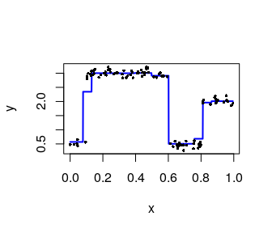

Figure 1. Total variation solution for piecewise constant function at best cross-validated model.

```r
plot(fit)
```

The $\tt{plot}$ function can also be used to see fits at other values of $\lambda$, such as lambda corresponding to 1 standard error rule (for greater parsimony) or an arbitrary number:

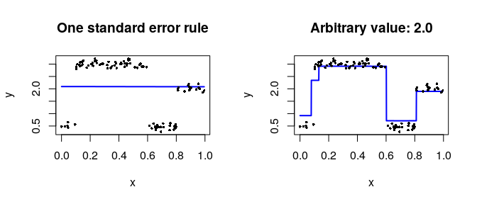

Figure 2. Total variation solution for piecewise constant function at other solutions.

```r
par(mfrow=c(1,2))
plot(fit, lambda = fit$lambda.1se)
title(main = "One standard error rule")
plot(fit, lambda = 2.0)
title(main = "Arbitrary value: 2.0")
```

Aside from the number of knots, the user can also define the mesh itself. In Figure 3, we show that by setting $m=N$ and $d_1=x_1,\ldots,d_N=x_N$, we return the fused lasso solution (R. Tibshirani et al. 2005, Arnold and Tibshirani (2014)).

```r
par(mfrow=c(1,2))
set.seed(123) # Setting a seed for cross-validation procedure
m <- matrix(N,ncol=1)
xsorted <- sort(x, index.return=TRUE)
mesh <- matrix(xsorted$x, ncol = 1)
ysorted <- matrix(y[xsorted$ix], ncol = 1)
fl_mvtv <- mvtv(mesh,ysorted,m,mesh = mesh, verbose=FALSE) # Verbose = FALSE to suppress algorithm details
plot(fl_mvtv)
title(sub = "(a)")

library(genlasso)
fl_genlasso <- fusedlasso1d(ysorted)
cvfl <- cv.trendfilter(fl_genlasso,verbose = FALSE)
```

```
#> Fold 1 ... Fold 2 ... Fold 3 ... Fold 4 ... Fold 5 ...
```

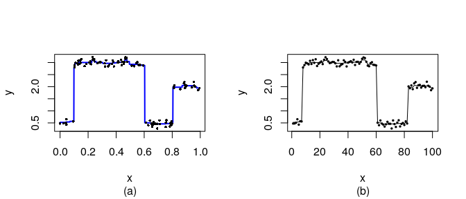

Figure 3. (a) Fused lasso given by MultivarTV. (b) Fused lasso given by genlasso.

```r
plot(fl_genlasso,lambda=cvfl$lambda.min,xlab = "x",ylab="y",pch=20,cex=0.5)
title(sub = "(b)")
```

# $\bf{MultivarTV}$ for Multivariate Data

For multivariate data, the total variation problem becomes difficult. Let $(x_1,\dlots,x_p)$ denote $p$ covariates. Furthermore, we define a multi-index $r=(r_1,\ldots,r_p)$, where $r_j\in \{0,1\}$ and $|r| = \sum_{j=1}^p r_j$. In our approach, we approximate the penalty
$$P(f) = \sum_{r\in \{0,1\}^p} \int \left|\frac{\partial^{|r|}}{\partial^{r_1}x_1 \ldots \partial^{r_p}x_p}f(x)\right|\partial x_1\ldots \partial x_p,$$
where $\{0,1\}^p\equiv \{0,1\} \times \ldots \times \{0,1\}$, i.e. the Cartesian product. In the bivariate setting, our penalty parameter becomes
$$P(f) = \int \left|\frac{\partial}{\partial x_1} f(x_1, x_2) \right|\partial x_1\partial x_2 +\int \left|\frac{\partial}{\partial x_2} f(x_1, x_2) \right|\partial x_1\partial x_2+\int \left|\frac{\partial}{\partial x_1 \partial x_2} f(x_1, x_2) \right|\partial x_1\partial x_2.$$
When $P(f)$ is finite, solutions have bounded total variation. $\bf{MultivarTV}$ continues to approximate $P(f)$ using differences across a mesh. For details, see Ortiz and Simon (2018). We can fit the multivariate problem using the same ADMM algorithm as in the univariate case, so $\tt{mvtv}$ uses the same algorithm regardless of dimensionality.

## Towers Function

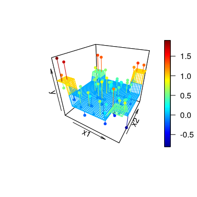

Figure 4. Plot of N=100 points drawn from Towers function (drawn as mesh) with noise.

The noisy towers can be fit well by a total variation solution. In this example, we will also compare the total variation fit against a thin plate spline, the generalization of smoothing splines (Duchon 1977) fit using the **fields** package (Furrer, Nychka, and Sain 2009). Based on Figure 5, we indeed get four towers from our total variation solution. In Figure 6, we see the thin plate spline solution, which is much more smooth and provides hills instead of towers.

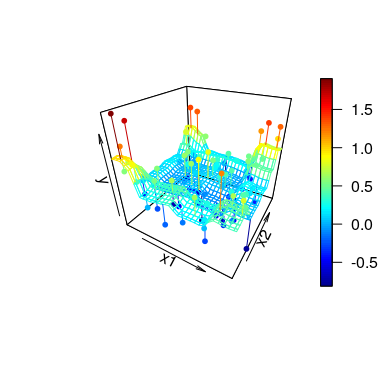

Figure 5. Total variation solution for noisy towers.

```r
set.seed(117)
mym <- floor(length(ynoisy)^{2/3})
mym <- matrix(rep(mym,2),ncol=1)
data <- cbind(z1,z2)
tvmod <- mvtv(data,ynoisy,mym,verbose=FALSE)
plot(tvmod,adddata = TRUE)
```

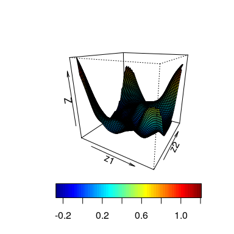

Figure 6. Thin plate spline solution for noisy towers.

```r
fit <- Tps(data,ynoisy)
out.p <- predictSurface(fit, xy = c(1,2))
plot.surface(out.p, type="p")
```

As we increase the sample size to $N=5,000$, the total variation solution improves (Figure 7). The thin plate spline solution takes a large amount of time to calculate, so we do not present it.

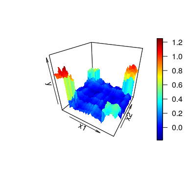

Figure 7. Total variation solution for noisy towers with many data points.

```r
set.seed(117)
z1 <- runif(5000)
z2 <- runif(5000)
z3 <- towers(z1,z2)
ynoisy <- z3 + rnorm(length(z3),0,0.5)
data <- cbind(z1,z2)

mym <- floor(length(ynoisy)^{1/2})
mym <- matrix(rep(mym,2),ncol=1)
tvmod <- mvtv(data,ynoisy,mym,verbose=FALSE)
plot(tvmod,adddata = FALSE)
```

# Notes and Limitations

The regression model used by **MultivarTV** performs optimally when the distance between the observations and the mesh points is small. In order to minimize that distance, we need to increase the number of knots. **MultivarTV** allows the user to specify $m_j$ knots per feature $x_j$. It will be best practice to choose a same large number of knots per each feature and allow regularization to smooth the solution. However, as we discuss next, the number of features does impact the functionality of **MultivarTV**.

The primary implementation function $\tt{mvtv}$ accepts any number of features. However, the generic $\tt{plot}$ function does not accept $\tt{mvtv}$-objects built on $p>2$. We can still plot the residuals versus fitted values for any size problem using the $\tt{plotResiduals}$ function:

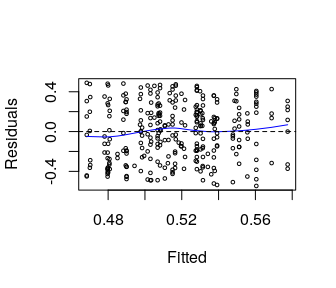

```r
set.seed(117)
n <- 300
p <- 3
m <- 4
data <- matrix(runif(n*p),ncol = p)
y <- matrix(runif(n), ncol=1)
m <- matrix(rep(m,p))
set.seed(123) # cvfold will yield different stuff without seed
tv3 <- mvtv(data,y,m,verbose = FALSE)

plotResiduals(tv3)
```

For uniform noisy data regressed on uniform noisy trivariate data, we expect fitted values at the mean and evenly dispersed residuals, which is what we see with some small wiggling (Figure 8).

The larger issue with the number of features has to do with scaling. Using the same number of knots for each feature, the number of optimization parameters is $m^p$. For modest $m$ and large $p$, the difference matrices (even though they are stored as sparse matrices) become larger than most personal laptops can store. We recommend a large number of knots, $m>N^{\frac{2}{3}}$, for a quality solution, but it may be best practice to use fewer at experimental stages.

# Bibliography

Arnold, Taylor B, and Ryan J Tibshirani. 2014. “Genlasso: Path Algorithm for Generalized Lasso Problems.” *R Package Version* 1.

Boyd, Stephen, Neal Parikh, Eric Chu, Borja Peleato, and Jonathan Eckstein. 2011. “Distributed Optimization and Statistical Learning via the Alternating Direction Method of Multipliers.” *Foundations and Trends in Machine Learning* 3 (1). Now Publishers Inc.: 1–122.

Duchon, Jean. 1977. “Splines Minimizing Rotation-Invariant Semi-Norms in Sobolev Spaces.” In *Constructive Theory of Functions of Several Variables*, 85–100. Springer.

Furrer, Reinhard, Douglas Nychka, and Stephen Sain. 2009. “Fields: Tools for Spatial Data.” *R Package Version* 6 (11).

Ortiz, Brayan, and Noah Simon. 2018. “Mesh Based Solutions to Nonparametrix Regression.” *arXiv Preprint*.

Tibshirani, Robert, Michael Saunders, Saharon Rosset, Ji Zhu, and Keith Knight. 2005. “Sparsity and Smoothness via the Fused Lasso.” *Journal of the Royal Statistical Society: Series B (Statistical Methodology)* 67 (1). Wiley Online Library: 91–108.